# R Notebook

```r
library(rpart)
library(rpart.plot)
library(tidyverse)
library(modelr)
library(caret)

titanic_set <- read_csv('data/titanic_decision_tree_data.csv')

shuffle_index <- sample(1:nrow(titanic_set))

# shuffle the data so class order isn't in order - need this for training/testing split later on
titanic_set <- titanic_set[shuffle_index, ]
```

# MVP

## Question 1

```r
titanic_set_tidy <- titanic_set %>%
  janitor::clean_names() %>%
  filter(!is.na(survived)) %>%
  mutate(sex = as.factor(sex),
         age_status = as.factor(if_else(age <= 16, "child", "adult")),
         class = factor(pclass,
                        levels = c(1, 2, 3),
                        labels = c("upper", "middle", "lower")),
         port_embarkation = as.factor(embarked),
         survived_flag = factor(survived,
                                levels = c(0, 1),
                                labels = c("no", "yes"))) %>%
  select(sex, age_status, class, port_embarkation,
         sib_sp, parch, survived_flag) %>%
  drop_na()
```

## Question 2

```r
GGally::ggpairs(titanic_set_tidy)
```

[output not shown]

Seems like sex and class might be useful in predicting whether a passenger is going to die.

## Question 3

I chose an 80/20 split, since there are not that many observations in the dataset.

```r
n_data <- nrow(titanic_set_tidy)

test_index <- sample(1:n_data, size = n_data * 0.2)

titanic_test <- slice(titanic_set_tidy, test_index)
titanic_train <- slice(titanic_set_tidy, -test_index)
```

```r
titanic_test %>%
  janitor::tabyl(survived_flag)

titanic_train %>%
  janitor::tabyl(survived_flag)
```

[output not shown]

```r
titanic_sample <-
  splitstackshape::stratified(titanic_set_tidy,
                              group = "survived_flag",
                              size = 0.2,
                              bothSets = TRUE)
```

```r
titanic_test <- titanic_sample$SAMP1
titanic_train <- titanic_sample$SAMP2
```

```r
titanic_test %>%
  janitor::tabyl(survived_flag)
```

```
 survived_flag  n   percent
            no 85 0.5944056
           yes 58 0.4055944
```

```r
titanic_train %>%
  janitor::tabyl(survived_flag)
```

```
 survived_flag   n   percent
            no 339 0.5957821
           yes 230 0.4042179
```

# Question 4

```r
titanic_fit <- rpart(survived_flag ~ .,
                     data = titanic_train,
                     method = "class")
```

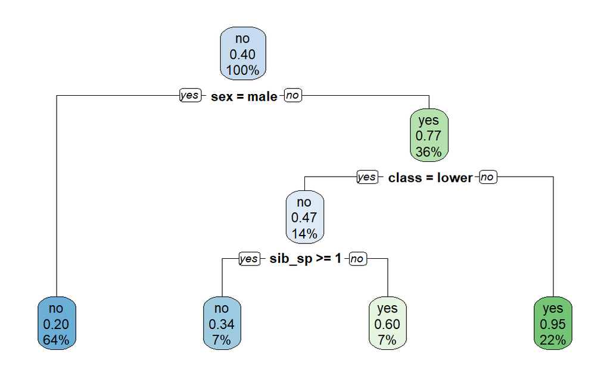

```r
rpart.plot(titanic_fit,
           yesno = 2,
           fallen.leaves = TRUE)
```

# Question 5

So, ignoring these, the map is telling us that males have only 0.2 chance of survival, while for females it’s 0.77. Females that are not in the lower class have a 0.95 chance of surviving, while females in the lower class have a 0.47 chance of surviving. Then, females in the lower class that have one or more siblings or spouses have a 0.34 chance of surviving and ones that have none have a 0.60 chance of surviving.

The important variables in this tree map are sex, class and sib_sp.

# Question 6

```r
titanic_test_pred <- titanic_test %>%
  add_predictions(titanic_fit, type = "class")
```

```r
confusionMatrix(titanic_test_pred$pred,
                titanic_test_pred$survived_flag)
```

```
Confusion Matrix and Statistics

          Reference
Prediction no yes
       no  74  25
       yes 11  33

               Accuracy : 0.7483
                 95% CI : (0.6689, 0.817)
    No Information Rate : 0.5944
    P-Value [Acc > NIR] : 8.385e-05

                  Kappa : 0.4571

 Mcnemar's Test P-Value : 0.03026

            Sensitivity : 0.8706
            Specificity : 0.5690
         Pos Pred Value : 0.7475
         Neg Pred Value : 0.7500
             Prevalence : 0.5944
         Detection Rate : 0.5175
   Detection Prevalence : 0.6923
      Balanced Accuracy : 0.7198

       'Positive' Class : no
```

In terms of this dataset, the model correctly predicted the 74 people that didn’t survive, and 33 people that did. It also incorrectly predicted the survival of 11 people and the death of 25.